# Project Foundations for Data Science: FoodHub Data Analysis

**Marks: 60**

### Context

The number of restaurants in New York is increasing day by day. Lots of students and busy professionals rely on those restaurants due to their hectic lifestyles. Online food delivery service is a great option for them. It provides them with good food from their favorite restaurants. A food aggregator company FoodHub offers access to multiple restaurants through a single smartphone app.

The app allows the restaurants to receive a direct online order from a customer. The app assigns a delivery person from the company to pick up the order after it is confirmed by the restaurant. The delivery person then uses the map to reach the restaurant and waits for the food package. Once the food package is handed over to the delivery person, he/she confirms the pick-up in the app and travels to the customer's location to deliver the food. The delivery person confirms the drop-off in the app after delivering the food package to the customer. The customer can rate the order in the app. The food aggregator earns money by collecting a fixed margin of the delivery order from the restaurants.

### Objective

The food aggregator company has stored the data of the different orders made by the registered customers in their online portal. They want to analyze the data to get a fair idea about the demand of different restaurants which will help them in enhancing their customer experience. Suppose you are hired as a Data Scientist in this company and the Data Science team has shared some of the key questions that need to be answered. Perform the data analysis to find answers to these questions that will help the company to improve the business.

### Data Description

The data contains the different data related to a food order. The detailed data dictionary is given below.

### Data Dictionary

- order_id: Unique ID of the order
- customer_id: ID of the customer who ordered the food
- restaurant_name: Name of the restaurant
- cuisine_type: Cuisine ordered by the customer
- cost: Cost of the order
- day_of_the_week: Indicates whether the order is placed on a weekday or weekend (The weekday is from Monday to Friday and the weekend is Saturday and Sunday)
- rating: Rating given by the customer out of 5
- food_preparation_time: Time (in minutes) taken by the restaurant to prepare the food. This is calculated by taking the difference between the timestamps of the restaurant's order confirmation and the delivery person's pick-up confirmation.
- delivery_time: Time (in minutes) taken by the delivery person to deliver the food package. This is calculated by taking the difference between the timestamps of the delivery person's pick-up confirmation and drop-off information

### Let us start by importing the required libraries

```python
# import libraries for data manipulation
import numpy as np
import pandas as pd

# import libraries for data visualization
import matplotlib.pyplot as plt
import seaborn as sns
```

```python
import numpy as np
print(np.__version__)
```

```
2.0.1
```

### Understanding the structure of the data

```python
# read the data
df = pd.read_csv('foodhub_order (1).csv')
# returns the first 5 rows
df.head()
```

|  | order_id | customer_id | restaurant_name | cuisine_type | cost_of_the_order | day_of_the_week | rating | food_preparation_time | delivery_time |
| --- | --- | --- | --- | --- | --- | --- | --- | --- | --- |
| 0 | 1477147 | 337525 | Hangawi | Korean | 30.75 | Weekend | Not given | 25 | 20 |
| 1 | 1477685 | 358141 | Blue Ribbon Sushi Izakaya | Japanese | 12.08 | Weekend | Not given | 25 | 23 |
| 2 | 1477070 | 66393 | Cafe Habana | Mexican | 12.23 | Weekday | 5 | 23 | 28 |
| 3 | 1477334 | 106968 | Blue Ribbon Fried Chicken | American | 29.20 | Weekend | 3 | 25 | 15 |
| 4 | 1478249 | 76942 | Dirty Bird to Go | American | 11.59 | Weekday | 4 | 25 | 24 |

```python
# Observations:

#The DataFrame has 9 columns as mentioned in the Data Dictionary. Data in each row corresponds to the order placed
#by a customer. Also the data shows if it is a weekday or weekend but doesn't specify which day of the week.
#The rating column has Not given as well as numeric values.
```

### **Question 1:** How many rows and columns are present in the data? [0.5 mark]

```python
df.shape
```

```
(1898, 9)
```

#### Observations:

The DataFrame has 1898 rows, and 9 columns

### **Question 2:** What are the datatypes of the different columns in the dataset? (The info() function can be used) [0.5 mark]

```python
df.info()
```

```
<class 'pandas.core.frame.DataFrame'>
RangeIndex: 1898 entries, 0 to 1897
Data columns (total 9 columns):
 #   Column                 Non-Null Count  Dtype
---  ------                 --------------  -----
 0   order_id               1898 non-null   int64
 1   customer_id            1898 non-null   int64
 2   restaurant_name        1898 non-null   object
 3   cuisine_type           1898 non-null   object
 4   cost_of_the_order      1898 non-null   float64
 5   day_of_the_week        1898 non-null   object
 6   rating                 1898 non-null   object
 7   food_preparation_time  1898 non-null   int64
 8   delivery_time          1898 non-null   int64
dtypes: float64(1), int64(4), object(4)
memory usage: 133.6+ KB
```

#### Observations:

There are 3 data types, integer, object (string) and float. The count of non-null enteries is all equal, which means there is no missing data!

### **Question 3:** Are there any missing values in the data? If yes, treat them using an appropriate method. [1 mark]

```python
df.isnull().sum()
```

```
order_id                 0
customer_id              0
restaurant_name          0
cuisine_type             0
cost_of_the_order        0
day_of_the_week          0
rating                   0
food_preparation_time    0
delivery_time            0
dtype: int64
```

#### Observations:

There is no missing data, which confirms the previous finding that the count of all non-null enteries for all columns are equal.

### **Question 4:**

Check the statistical summary of the data. What is the minimum, average, and maximum time it takes for food to be prepared once an order is placed? [2 marks]

```python
df.describe().T
```

|  | count | mean | std | min | 25% | 50% | 75% | max |
| --- | --- | --- | --- | --- | --- | --- | --- | --- |
| order_id | 1898.0 | 1.477496e+06 | 548.049724 | 1476547.00 | 1477021.25 | 1477495.50 | 1.477970e+06 | 1478444.00 |
| customer_id | 1898.0 | 1.711685e+05 | 113698.139743 | 1311.00 | 77787.75 | 128600.00 | 2.705250e+05 | 405334.00 |
| cost_of_the_order | 1898.0 | 1.649885e+01 | 7.483812 | 4.47 | 12.08 | 14.14 | 2.229750e+01 | 35.41 |
| food_preparation_time | 1898.0 | 2.737197e+01 | 4.632481 | 20.00 | 23.00 | 27.00 | 3.100000e+01 | 35.00 |
| delivery_time | 1898.0 | 2.416175e+01 | 4.972637 | 15.00 | 20.00 | 25.00 | 2.800000e+01 | 33.00 |

#### Observations:

- The minimum time it takes for food preparation is 20 minutes.
- The average time it takes for food preparation is 27 minutes.
- the Maximum time it takes for food preparation is 35 minutes.

### **Question 5:** How many orders are not rated? [1 mark]

```python
# List the unique values
df['rating'].unique()
```

```
array(['Not given', '5', '3', '4'], dtype=object)
```

```python
# How many was each rate used?
df['rating'].value_counts()
```

```
rating
Not given    736
5            588
4            386
3            188
Name: count, dtype: int64
```

```python
# What is the percentage of each rating?
df['rating'].value_counts(normalize=True)
```

```
rating
Not given    0.387777
5            0.309800
4            0.203372
3            0.099052
Name: proportion, dtype: float64
```

#### Observations:

There are 736 non-rated orders, that is 39% of the orders were not rated by the customer. 31% were rated at 5, 20% received a rating of 4 , and 10% recieved a 3-star rating.

### Exploratory Data Analysis (EDA)

### **Question 6:** Explore all the variables and provide observations on their distributions. (Generally, histograms, boxplots, countplots, etc. are used for univariate exploration.) [9 marks]

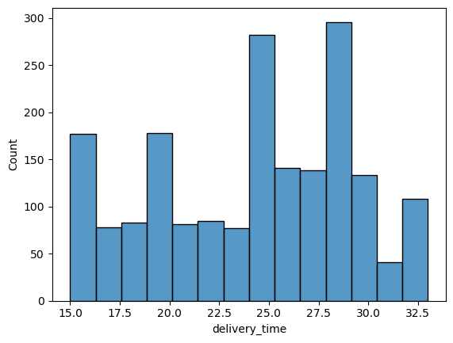

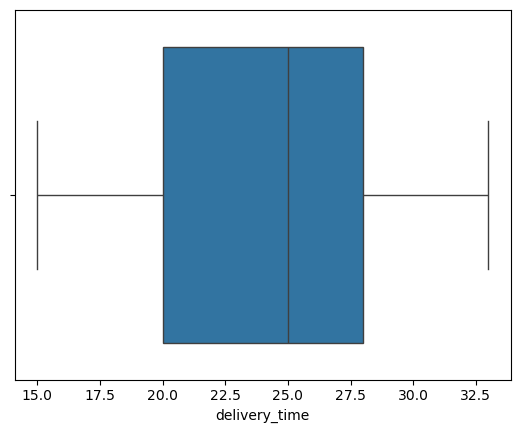

```python
sns.histplot(data=df, x='delivery_time')
plt.show()
sns.boxplot(data=df, x='delivery_time')
plt.show()
```

```python
# The median delivery time across all restaurents is 25 minutes. 25% of the restaurents is at 20 minutes delivery time.
# and 25% (75th percentile)is at 28 minutes.
```

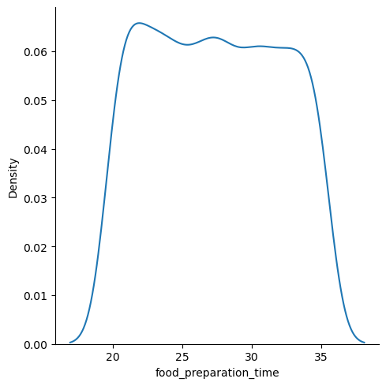

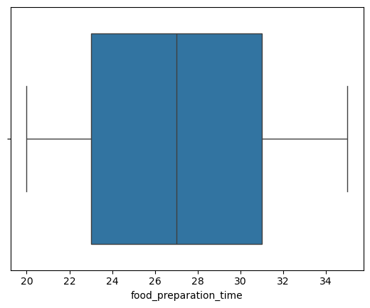

```python
sns.displot(data=df, x='food_preparation_time', kind='kde')
plt.show()
sns.boxplot(data=df, x='food_preparation_time')
plt.show()
```

```python
# The median food preparation time across all restaurents is 27 minutes. 25% of the restaurents is at 23 minutes.
# and 25% (75th percentile)is at 31 minutes.
```

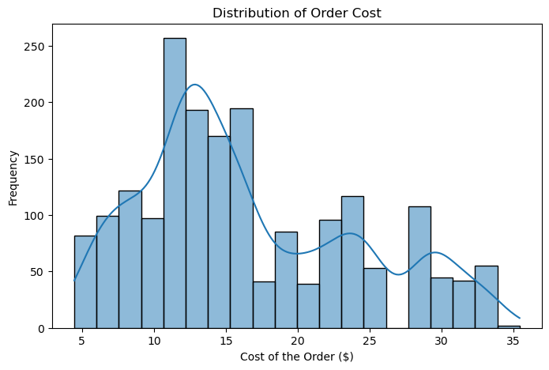

```python
# # Histogram: Distribution of Order Cost ---
plt.figure(figsize=(8, 5))
sns.histplot(df["cost_of_the_order"], bins=20, kde=True)
plt.xlabel("Cost of the Order ($)")
plt.ylabel("Frequency")
plt.title("Distribution of Order Cost")
plt.show()
```

```python
# The orders costing over $10 and less than $15 have the highest frequency.
```

### **Question 7**: Which are the top 5 restaurants in terms of the number of orders received? [1 mark]

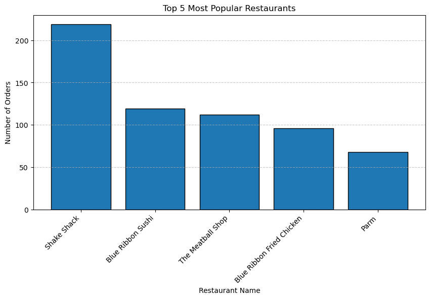

```python
order_counts = df.groupby(['restaurant_name', 'cuisine_type']).size().reset_index(name='order_count')

# Sort the data by order count in descending order
order_counts = order_counts.sort_values(by='order_count', ascending=False)

# Select the top 5 restaurants
top_5_restaurants = order_counts.head(5)

# Print the result
# print(top_5_restaurants)

# Plot the results
plt.figure(figsize=(10, 5))
plt.bar(top_5_restaurants['restaurant_name'], top_5_restaurants['order_count'], edgecolor='black')

# Labels and title
plt.xlabel("Restaurant Name")
plt.ylabel("Number of Orders")
plt.title("Top 5 Most Popular Restaurants")
plt.xticks(rotation=45, ha="right")
plt.grid(axis="y", linestyle="--", alpha=0.7)

# Show the plot
plt.show()
```

#### Observations: The top 5 most popular restaurents are :

# 1 Shake shack

# 2 Blue Ribbon Sushi

# 3 The Meatball Shop

# 4 Blue Ribbon Fried chicken

# 5 Parm

### **Question 8**: Which is the most popular cuisine on weekends? [1 mark]

```python
df['day_of_the_week'].unique()
```

```
array(['Weekend', 'Weekday'], dtype=object)
```

```
Most Popular Cuisines on Weekends:
```

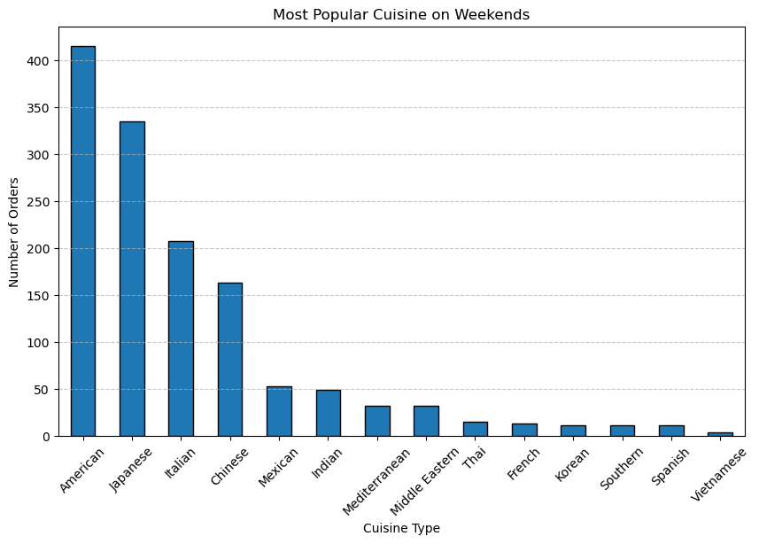

```python
# Filter for weekend orders
weekend_df = df[df['day_of_the_week'] == 'Weekend']

# Count cuisine occurrences
cuisine_counts = weekend_df['cuisine_type'].value_counts()

# Print the top cuisines on weekends
print("Most Popular Cuisines on Weekends:\n")
#print(cuisine_counts)

# Plot the results
plt.figure(figsize=(10, 6))
cuisine_counts.plot(kind='bar', edgecolor='black')

plt.xlabel("Cuisine Type")
plt.ylabel("Number of Orders")
plt.title("Most Popular Cuisine on Weekends")
plt.xticks(rotation=45)
plt.grid(axis='y', linestyle='--', alpha=0.7)

# Show the plot
plt.show()
```

```python
#OBSERVATIONS:  The most popular Cuisine in Weekends is teh American Cuisine.
```

```python
# Counting the number of orders for each restaurant and day_of_week
order_counts = df.groupby(['restaurant_name', 'day_of_the_week']).size().reset_index(name='order_count')

# Separating the data for weekends and weekdays, and sort ascending to show top 5
weekend_orders = order_counts[order_counts['day_of_the_week'] == 'Weekend'].sort_values(by='order_count', ascending=False).head(5)
weekday_orders = order_counts[order_counts['day_of_the_week'] == 'Weekday'].sort_values(by='order_count', ascending=False).head(5)

# Displaying the results
print("Weekend Orders:")
print(weekend_orders)

print("\nWeekday Orders:")
print(weekday_orders)
```

```
Weekend Orders:
               restaurant_name day_of_the_week  order_count
209                Shake Shack         Weekend          145
236          The Meatball Shop         Weekend           95
35           Blue Ribbon Sushi         Weekend           85
33   Blue Ribbon Fried Chicken         Weekend           74
186           RedFarm Broadway         Weekend           44

Weekday Orders:
               restaurant_name day_of_the_week  order_count
208                Shake Shack         Weekday           74
235          The Meatball Shop         Weekday           37
34           Blue Ribbon Sushi         Weekday           34
168                       Parm         Weekday           26
32   Blue Ribbon Fried Chicken         Weekday           22
```

```python
#OBSERVATIONS:  the most popular restaurent in weekends and weekdays is the American restaurent Shake Shack
```

### **Question 9**: What percentage of the orders cost more than 20 dollars? [2 marks]

```
Percentage of orders costing more than $20: 29.24%
```

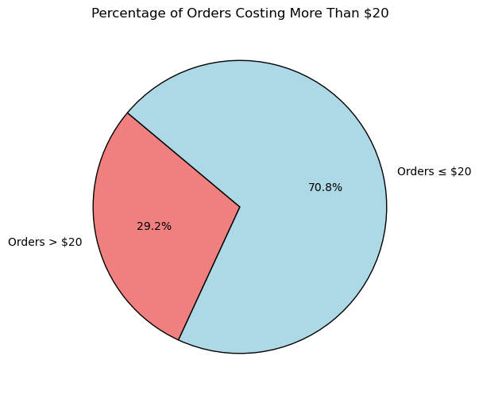

```python
# Calculate total orders
total_orders = len(df)

# Count orders where cost is more than $20
orders_above_20 = len(df[df["cost_of_the_order"] > 20])

# Calculate percentage
percentage_above_20 = (orders_above_20 / total_orders) * 100

# Print the result
print(f"Percentage of orders costing more than $20: {percentage_above_20:.2f}%")

# Plot the results using a pie chart
labels = ["Orders > $20", "Orders ≤ $20"]
sizes = [orders_above_20, total_orders - orders_above_20]
colors = ["lightcoral", "lightblue"]

plt.figure(figsize=(6, 6))
plt.pie(sizes, labels=labels, autopct="%1.1f%%", colors=colors, startangle=140, wedgeprops={"edgecolor": "black"})
plt.title("Percentage of Orders Costing More Than $20")
plt.show()
```

### **Question 10**: What is the mean order delivery time? [1 mark]

```
Mean Order Delivery Time: 24.16 minutes
```

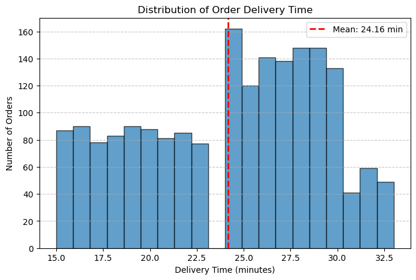

```python
# Calculate the mean delivery time
mean_delivery_time = df["delivery_time"].mean()

# Print the result
print(f"Mean Order Delivery Time: {mean_delivery_time:.2f} minutes")

# Plot the distribution of delivery times using a histogram
plt.figure(figsize=(8, 5))
plt.hist(df["delivery_time"], bins=20, edgecolor="black", alpha=0.7)
plt.axvline(mean_delivery_time, color="red", linestyle="dashed", linewidth=2, label=f"Mean: {mean_delivery_time:.2f} min")

# Labels and title
plt.xlabel("Delivery Time (minutes)")
plt.ylabel("Number of Orders")
plt.title("Distribution of Order Delivery Time")
plt.legend()
plt.grid(axis="y", linestyle="--", alpha=0.7)

# Show the plot
plt.show()
```

#### Observations:

the mean order delivery time is 24.16

### **Question 11:** The company has decided to give 20% discount vouchers to the top 3 most frequent customers. Find the IDs of these customers and the number of orders they placed. [1 mark]

```
Top 3 Customers for Discount Vouchers:
   customer_id  order_count
0        52832           13
1        47440           10
2        83287            9
```

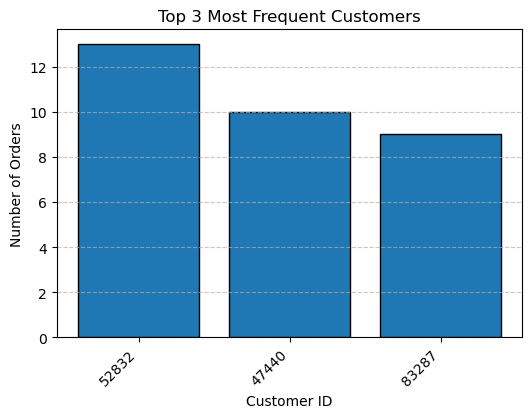

```python
# Count the number of orders per customer
customer_orders = df["customer_id"].value_counts().reset_index()
customer_orders.columns = ["customer_id", "order_count"]

# Select the top 3 most frequent customers
top_3_customers = customer_orders.head(3)

# Print the result
print("Top 3 Customers for Discount Vouchers:")
print(top_3_customers)

# Plot the results using a bar chart
plt.figure(figsize=(6, 4))
plt.bar(top_3_customers["customer_id"].astype(str), top_3_customers["order_count"], edgecolor="black")

# Labels and title
plt.xlabel("Customer ID")
plt.ylabel("Number of Orders")
plt.title("Top 3 Most Frequent Customers")
plt.xticks(rotation=45, ha="right")
plt.grid(axis="y", linestyle="--", alpha=0.7)

# Show the plot
plt.show()
```

#### Observations:the customer id for top 3 most frequent customers:

# 1 52832 - made 13 orders

# 2 47440 - made 10 oders

# 3 83287 - made 9 orders

### **Question 12**: Perform a multivariate analysis to explore relationships between the important variables in the dataset. (It is a good idea to explore relations between numerical variables as well as relations between numerical and categorical variables) [10 marks]

```python
## RATINGS
#The ratings column has a datatype "object", there is a value "Not given" , in order to check correlation
# and build insight , we need to convert rating column to numeric. however, we do not want to affect the rest
# of the dataframe by dropping columns that have other useful information, just because the custimer didnt give
# a rating. For that, I am copying the dataframe and using the copied data only to build inference
# about ratings!
```

```python
#copy dataframe , so changes doesn't affect original data
df_copy = df.copy()

# Replace 'Not given' in the 'rating' column with NaN
df_copy['rating'] = df_copy['rating'].replace('Not given', np.nan)
```

```python
# check values
df_copy['rating'].unique()
```

```
array([nan, '5', '3', '4'], dtype=object)
```

```python
#drop rows with rating nan
df_copy = df_copy.dropna(subset=['rating'])
df_copy['rating'].unique()

# Convert the 'rating' column to numeric
df_copy['rating'] = pd.to_numeric(df_copy['rating'])
```

```python
#check df_copy datatypes
df_copy.info()
```

```
<class 'pandas.core.frame.DataFrame'>
Index: 1162 entries, 2 to 1896
Data columns (total 9 columns):
 #   Column                 Non-Null Count  Dtype
---  ------                 --------------  -----
 0   order_id               1162 non-null   int64
 1   customer_id            1162 non-null   int64
 2   restaurant_name        1162 non-null   object
 3   cuisine_type           1162 non-null   object
 4   cost_of_the_order      1162 non-null   float64
 5   day_of_the_week        1162 non-null   object
 6   rating                 1162 non-null   int64
 7   food_preparation_time  1162 non-null   int64
 8   delivery_time          1162 non-null   int64
dtypes: float64(1), int64(5), object(3)
memory usage: 90.8+ KB
```

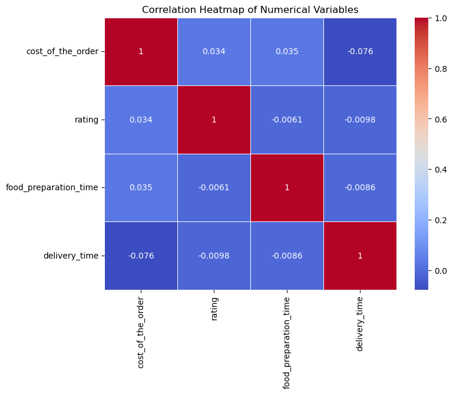

```python
# Correlation Heatmap
#check correlation between all columns with numeric values
plt.figure(figsize=(8, 6))
numeric_data = df_copy.select_dtypes(include=['number'])
numeric_data = numeric_data.drop(columns=['customer_id','order_id'])
sns.heatmap(numeric_data.corr(), annot = True, cmap="coolwarm", linewidths=0.5)
plt.title("Correlation Heatmap of Numerical Variables")
plt.show()
```

```python
# Observation: Looking at the above plot, it seems there is no strong correlations between the different numeric columns.
```

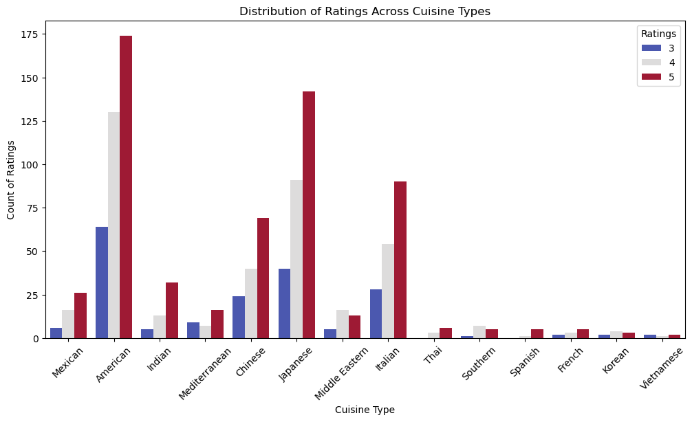

```python
# Ratings by Cuisine - (excluding rows with no ratings)

plt.figure(figsize=(12, 6))
sns.countplot(x=df_copy["cuisine_type"], hue=df_copy["rating"], palette="coolwarm")

plt.title("Distribution of Ratings Across Cuisine Types")
plt.xlabel("Cuisine Type")
plt.ylabel("Count of Ratings")
plt.xticks(rotation=45)  # Rotate x-axis labels for better readability
plt.legend(title="Ratings")
plt.show()
```

```python
# Observation: the figure above shows that the highest number of 5 start ratings goes to the American cuisine,
# followed by the japanese and Italian cuisines.
```

```python
# Compute average rating per restaurant
avg_rating_per_restaurant = df_copy.groupby("restaurant_name")["rating"].mean().sort_values(ascending=False)

# Get the top 20 and bottom 20 restaurants
top_20_restaurants = avg_rating_per_restaurant.head(20)
bottom_20_restaurants = avg_rating_per_restaurant.tail(20)

# Display results
print("Top 20 Restaurants by Rating:\n", top_20_restaurants)
print("\nBottom 20 Restaurants by Rating:\n", bottom_20_restaurants)
```

```
Top 20 Restaurants by Rating:
 restaurant_name
'wichcraft                       5.0
Ravagh Persian Grill             5.0
Chola Eclectic Indian Cuisine    5.0
Chote Nawab                      5.0
Junoon                           5.0
Socarrat Paella Bar              5.0
DespaÌ±a                         5.0
Dig Inn Seasonal Market          5.0
Saravanaa Bhavan                 5.0
Donburi-ya                       5.0
Dos Caminos                      5.0
Dos Caminos Soho                 5.0
Samurai Mama                     5.0
El Parador Cafe                  5.0
Prosperity Dumpling              5.0
Carmine's                        5.0
Galli Restaurant                 5.0
Grand Sichuan International      5.0
Philippe Chow                    5.0
Olive Garden                     5.0
Name: rating, dtype: float64

Bottom 20 Restaurants by Rating:
 restaurant_name
Dirty Bird to Go              4.000000
Rye House                     4.000000
DuMont Burger                 4.000000
Waverly Diner                 3.750000
Sarabeth's East               3.666667
The Odeon                     3.500000
Pylos                         3.500000
Terakawa Ramen                3.500000
Go! Go! Curry!                3.500000
Don's Bogam BBQ & Wine Bar    3.500000
Blue Ribbon Brooklyn          3.333333
Cafeteria                     3.250000
brgr                          3.000000
Nha Trang One                 3.000000
Haveli Indian Restaurant      3.000000
Woorijip                      3.000000
Byblos Restaurant             3.000000
Pepe Giallo                   3.000000
Sushi Choshi                  3.000000
Sarabeth's West               3.000000
Name: rating, dtype: float64
```

```python
#OBSERVATIONS
#top 5 Rated restaurents:
#1 wichcraft
#2 Ravagh Persian Grill
#3 Chola Eclectic Indian Cuisine
#4 Chote Nawab
#5 Junoon

# Restaurents that received lowest rating (Last 8):
#1 brgr
#2 Nha Trang One
#3 Haveli Indian Restaurant
#4 Woorijip
#5 Byblos Restaurant
#6 Pepe Giallo
#7 Sushi Choshi
#8 Sarabeth's West
```

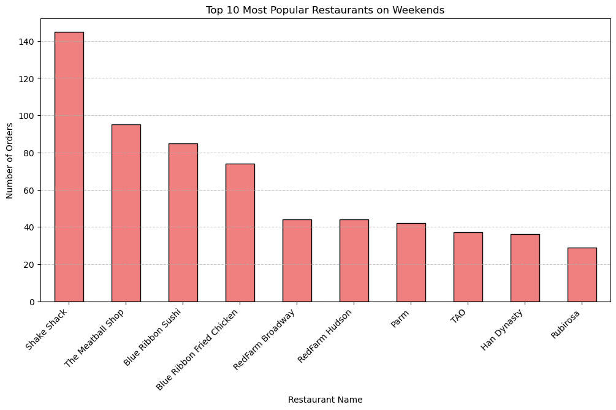

```python
# Filter data for weekends only
weekend_data = df[df["day_of_the_week"] == "Weekend"]

# Count orders per restaurant
restaurant_counts = weekend_data["restaurant_name"].value_counts().head(10)  # Top 10 restaurants

# Plot the results
plt.figure(figsize=(12, 6))
restaurant_counts.plot(kind="bar", color="lightcoral", edgecolor="black")
plt.xlabel("Restaurant Name")
plt.ylabel("Number of Orders")
plt.title("Top 10 Most Popular Restaurants on Weekends")
plt.xticks(rotation=45, ha="right")
plt.grid(axis="y", linestyle="--", alpha=0.7)

# Show the plot
plt.show()
```

```python
# During weekends Shake Shack , receives the highest number of orders, followed by meatball shop, and blue Ribbon sushi.
```

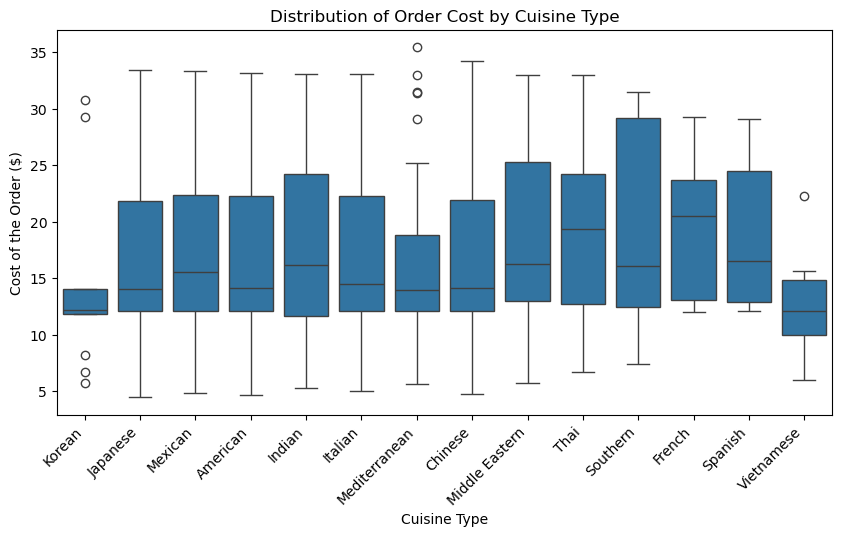

```python
# Delivery Time

plt.figure(figsize=(10, 5))
sns.boxplot(data=df,x='cuisine_type', y='cost_of_the_order')
plt.xticks(rotation=45, ha="right")
plt.title("Distribution of Order Cost by Cuisine Type")
plt.xlabel("Cuisine Type")
plt.ylabel("Cost of the Order ($)")
plt.show()
```

```python
# The French Cuisine has the hihghest median value in terms of order cost, followed by Thai.
# Vietnamese cuisine has the least median value for order cost
```

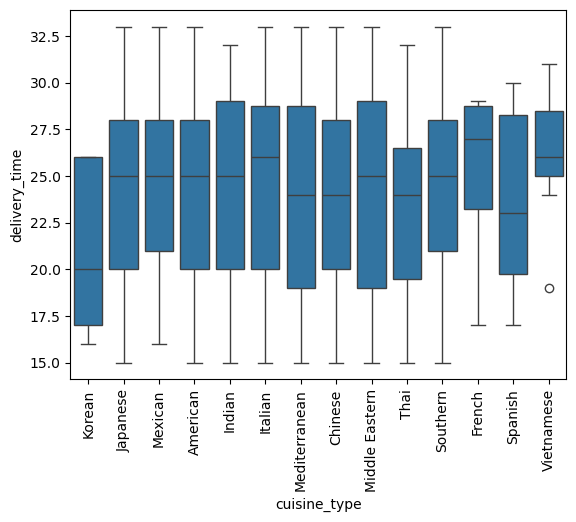

```python
sns.boxplot(data=df,x='cuisine_type', y='delivery_time')
plt.xticks(rotation=90)
plt.show()
```

```python
# The Korean cuisine has the least mediam delivry time of all (20 minutes), while french cuise has the longest median
# delivery time (a little less than 27.5 minutes)
```

```python
# Bar Chart: Most Popular Cuisine Types ---
plt.figure(figsize=(10, 5))
sns.countplot(x=df["cuisine_type"], order=df["cuisine_type"].value_counts().index, palette="coolwarm")
plt.xticks(rotation=45, ha="right")
plt.xlabel("Cuisine Type")
plt.ylabel("Number of Orders")
plt.title("Most Popular Cuisine Types")
plt.show()
```

[output not shown]

### **Question 13:** The company wants to provide a promotional offer in the advertisement of the restaurants. The condition to get the offer is that the restaurants must have a rating count of more than 50 and the average rating should be greater than 4. Find the restaurants fulfilling the criteria to get the promotional offer. [3 marks]

```python
# Use df_copy - the framework that dropped all ratings with value "not given", and chnaged datatype to numeric.

# Group by restaurant name and calculate the count & mean rating
restaurant_ratings = df_copy.groupby("restaurant_name")["rating"].agg(["count", "mean"]).reset_index()

# Rename columns for clarity
restaurant_ratings.columns = ["restaurant_name", "rating_count", "average_rating"]

# Apply the promotional offer conditions
eligible_restaurants = restaurant_ratings[
    (restaurant_ratings["rating_count"] > 50) & (restaurant_ratings["average_rating"] > 4)
]

# Display results
print(eligible_restaurants)
```

```
               restaurant_name  rating_count  average_rating
16   Blue Ribbon Fried Chicken            64        4.328125
17           Blue Ribbon Sushi            73        4.219178
117                Shake Shack           133        4.278195
132          The Meatball Shop            84        4.511905
```

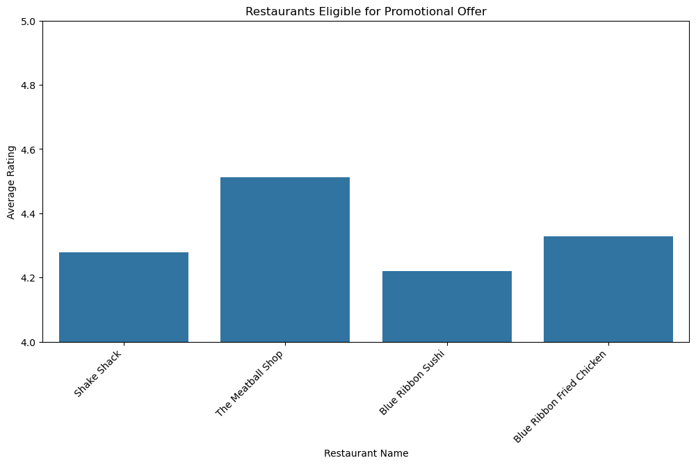

```python
# Sort by rating count for better visualization
eligible_restaurants = eligible_restaurants.sort_values(by="rating_count", ascending=False)

# Bar plot for average rating
plt.figure(figsize=(12, 6))
sns.barplot(x="restaurant_name", y="average_rating", data=eligible_restaurants)
plt.xticks(rotation=45, ha="right")
plt.xlabel("Restaurant Name")
plt.ylabel("Average Rating")
plt.title("Restaurants Eligible for Promotional Offer")
plt.ylim(4, 5)  # Ratings range from 4 to 5
plt.show()
```

#### Observations:

# the restaurents eligible for the promotional offer are :

# the meatball, blue ribbon fried chicken, shake shack, and blue ribbon sushi

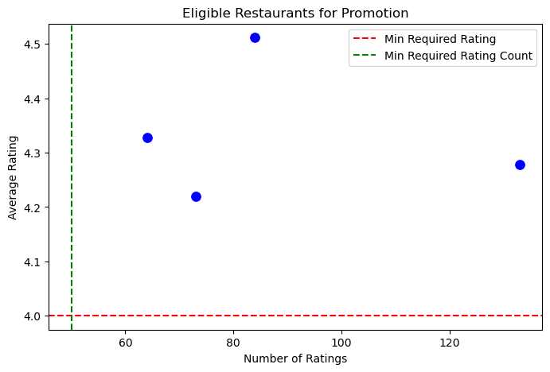

```python
# Try another way for plotting
plt.figure(figsize=(8, 5))
sns.scatterplot(x="rating_count", y="average_rating", data=eligible_restaurants, color="blue", s=100)
plt.axhline(y=4, color="red", linestyle="--", label="Min Required Rating")
plt.axvline(x=50, color="green", linestyle="--", label="Min Required Rating Count")
plt.xlabel("Number of Ratings")
plt.ylabel("Average Rating")
plt.title("Eligible Restaurants for Promotion")
plt.legend()
plt.show()
```

### **Question 14:** The company charges the restaurant 25% on the orders having cost greater than 20 dollars and 15% on the orders having cost greater than 5 dollars. Find the net revenue generated by the company across all orders. [3 marks]

```python
# commision structure
df["commission"] = df["cost_of_the_order"].apply(lambda x:
    0.25 * x if x > 20 else
    0.15 * x if x > 5 else
    0
)

# Calculate total revenue generated by the company
total_revenue = df["commission"].sum()

# Display result
print(f"Total Revenue Generated by the Company: ${total_revenue:.2f}")
```

```
Total Revenue Generated by the Company: $6166.30
```

#### Observations: The revenue is $6166.30

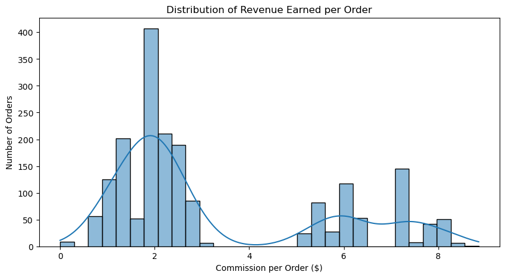

```python
plt.figure(figsize=(10, 5))
sns.histplot(df["commission"], bins=30, kde=True)
plt.xlabel("Commission per Order ($)")
plt.ylabel("Number of Orders")
plt.title("Distribution of Revenue Earned per Order")
plt.show()
```

### **Question 15:** The company wants to analyze the total time required to deliver the food. What percentage of orders take more than 60 minutes to get delivered from the time the order is placed? (The food has to be prepared and then delivered.) [2 marks]

```python
# Compute total time required for delivery
df["total_delivery_time"] = df["food_preparation_time"] + df["delivery_time"]

# Count total orders and those exceeding 60 minutes
total_orders = len(df)
orders_above_60 = len(df[df["total_delivery_time"] > 60])

# Calculate percentage
percentage_above_60 = (orders_above_60 / total_orders) * 100

# Display result
print(f"Percentage of orders taking more than 60 minutes: {percentage_above_60:.2f}%")
```

```
Percentage of orders taking more than 60 minutes: 10.54%
```

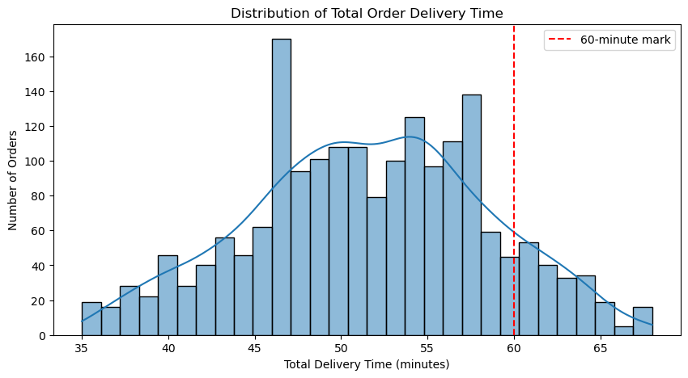

```python
plt.figure(figsize=(10, 5))
sns.histplot(df["total_delivery_time"], bins=30, kde=True)
plt.axvline(x=60, color="red", linestyle="--", label="60-minute mark")
plt.xlabel("Total Delivery Time (minutes)")
plt.ylabel("Number of Orders")
plt.title("Distribution of Total Order Delivery Time")
plt.legend()
plt.show()
```

#### Observations: Percentage of orders taking more than 60 minutes: 10.54%

### **Question 16:** The company wants to analyze the delivery time of the orders on weekdays and weekends. How does the mean delivery time vary during weekdays and weekends? [2 marks]

```python
# Calculate mean delivery time for weekdays and weekends
mean_delivery_time = df.groupby("day_of_the_week")["delivery_time"].mean()

# Display result
print(mean_delivery_time)
```

```
day_of_the_week
Weekday    28.340037
Weekend    22.470022
Name: delivery_time, dtype: float64
```

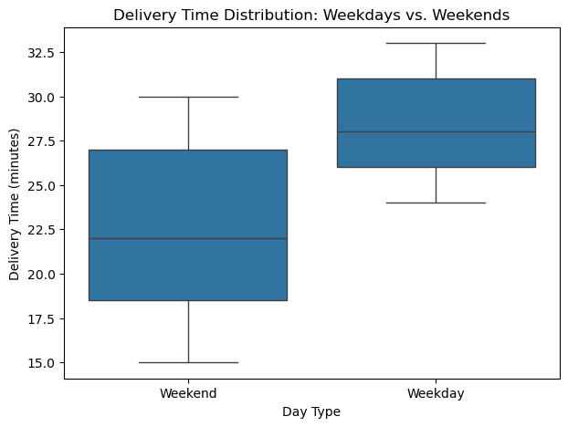

```python
plt.figure(figsize=(7, 5))
sns.boxplot(x="day_of_the_week", y="delivery_time", data=df )

# Formatting
plt.xlabel("Day Type")
plt.ylabel("Delivery Time (minutes)")
plt.title("Delivery Time Distribution: Weekdays vs. Weekends")
plt.show()
```

#### Observations:

My expectation was that delivery time during weekdays will actually be faster, since orders in weekends are more than those in weekdays! but what we see herer is the delivery time in weekend seem to be much faster around 22 minutes, versus 28 minutes in Weekdays.

### Conclusion and Recommendations

### **Question 17:** What are your conclusions from the analysis? What recommendations would you like to share to help improve the business? (You can use cuisine type and feedback ratings to drive your business recommendations.) [6 marks]

```python
cuisine_popularity = df_copy["cuisine_type"].value_counts()

# Average Rating by Cuisine
avg_rating_by_cuisine = df_copy.groupby("cuisine_type")["rating"].mean().sort_values(ascending=False)

# Print results
print("Cuisine Popularity:\n", cuisine_popularity)
print("\nAverage Rating by Cuisine:\n", avg_rating_by_cuisine)
```

```
Cuisine Popularity:
 cuisine_type
American          368
Japanese          273
Italian           172
Chinese           133
Indian             50
Mexican            48
Middle Eastern     34
Mediterranean      32
Southern           13
French             10
Thai                9
Korean              9
Spanish             6
Vietnamese          5
Name: count, dtype: int64

Average Rating by Cuisine:
 cuisine_type
Spanish           4.833333
Thai              4.666667
Indian            4.540000
Mexican           4.416667
Japanese          4.373626
Italian           4.360465
Chinese           4.338346
Southern          4.307692
French            4.300000
American          4.298913
Middle Eastern    4.235294
Mediterranean     4.218750
Korean            4.111111
Vietnamese        4.000000
Name: rating, dtype: float64
```

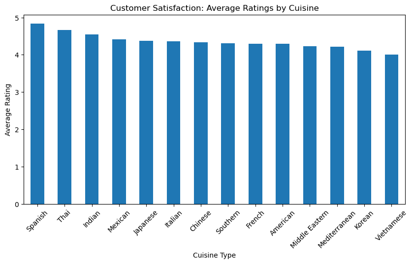

```python
plt.figure(figsize=(10, 5))
avg_rating_by_cuisine.plot(kind="bar")

plt.xlabel("Cuisine Type")
plt.ylabel("Average Rating")
plt.title("Customer Satisfaction: Average Ratings by Cuisine")
plt.xticks(rotation=45)
plt.show()
```

### Recommendations:

- 1 Encourage customers to rate the restuarent:
  - we will reward customers everytime thy agree to rate a restaurent performance.
  - If the customer orders oline or by phone and receives a delivery, if they agree to rate our performance, they will receive a discount card. Forcustomers dining in - they have the choice between discount card for their next order , or free dessert.
  - Use ratings to deepen our insights Ask the dine-in customers about taste of food, but also ask about service and food preparatin time. Ask the delivery customers about taste of food, but also ask about delivery time.
- 2 Knowledge transfer between restaurents While there are differences in food preparation times between restaurants, delivery system can be studied, we will check the way Korean restaurents manage their delivery, and study the feasability of applying the same system to restaurents that are much slower starting with the ones that take the most time i,e the french, vetnamese, and italian restaurents
- 3 Work with the restaurents that received the lowest ratings:

# 1 brgr

# 2 Nha Trang One

# 3 Haveli Indian Restaurant

# 4 Woorijip

# 5 Byblos Restaurant

# 6 Pepe Giallo

# 7 Sushi Choshi

# 8 Sarabeth's West

We will run an audit to figure out what are some obvious experience turn offs and fix them. We need to see the reasons behind these ratings, we will offer discounts to clients to come and try the food and see what part of the experience the customers do not like, or what mnu items are not liked. after these steps and making changes, we will run Ads. for these restaurents and highlighting their unique selling propositions.

- 4 Promote high-performing cuisines: Increase visibility for top-rated cuisines through marketing campaigns.
- 5 Optimize restaurant partnerships: Partner more with restaurants that consistently receive high ratings.